# Stat 432 Final Project - Classification Models

Pengyu Cheng, Bing Liang, Siyu Lai

12/6/2018

# Read Saved Data

```r
# Load Training data
data.train <- read.csv('TrainData_clf.csv')
data.test <- read.csv('TestData_clf.csv')
# sub data for svm
sub.idx.train <- sample(nrow(data.train), 10000)
sub.idx.test <- sample(nrow(data.test), 2000)
sub.x.train <- data.train[sub.idx.train, -ncol(data.train)]
sub.y.train <- as.factor(data.test[sub.idx.train, ncol(data.train)])
sub.x.test <- data.train[sub.idx.test, -ncol(data.test)]
sub.y.test <- as.factor(data.test[sub.idx.test, ncol(data.test)])
# whole data
X.train <- data.train[, -ncol(data.train)]
y.train <- as.factor(data.train[, ncol(data.train)])
X.test <- data.test[, -ncol(data.test)]
y.test <- as.factor(data.test[, ncol(data.test)])
```

# Neural Network

```r
library(tfestimators)
# return an input_fn for a given subset of data
response <- function() "ARRIVAL_DELAY_LEVEL"
features <- function() setdiff(names(X.train), response())
```

- construct feature columns

```r
feature_columns <- feature_columns(
  column_numeric(features())
)
```

- construct classifier
  - We use Adagrad optimizer and RELU activation function with no drop out rate after trying several combinations of hyperparameters. There are two layers in the network with 16 neurons and 8 neurous. The last layer is activated by logistic function by default for classification.

```r
classifier <- dnn_classifier(
  feature_columns = feature_columns,
  hidden_units = c(16, 8),
  n_classes = 4,
  model_dir = 'dnn.md.2.layer.final'
)
```

- construct input function

```r
input_fn_delay <- function(data, num_epochs) {
  input_fn(data,
           features = features(),
           response = response(),
           batch_size = 128,
           num_epochs = num_epochs)
}
```

## Training:

```r
tfestimators::train(classifier, input_fn = input_fn_delay(data.train, num_epochs=2))
```

## Predicting:

```r
predictions <- predict(classifier, input_fn = input_fn_delay(data.test, num_epochs=1))
```

## Confusion Matrix:

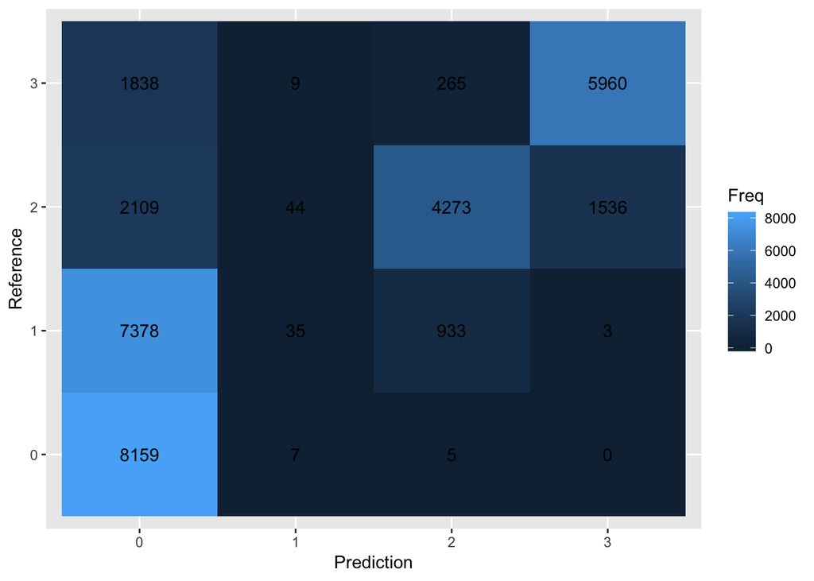

```r
y.pred <- as.numeric(unlist(predictions$classes))
cm <- confusionMatrix(as.factor(y.pred), as.factor(y.test))
ggplot(data <- as.data.frame(cm$table), aes(x=Prediction, y=Reference, fill=Freq)) + geom_tile() + geom_text(aes(label = Freq))
```

From the confusion matrix, we can clearly see the predicted class.

## Histogram:

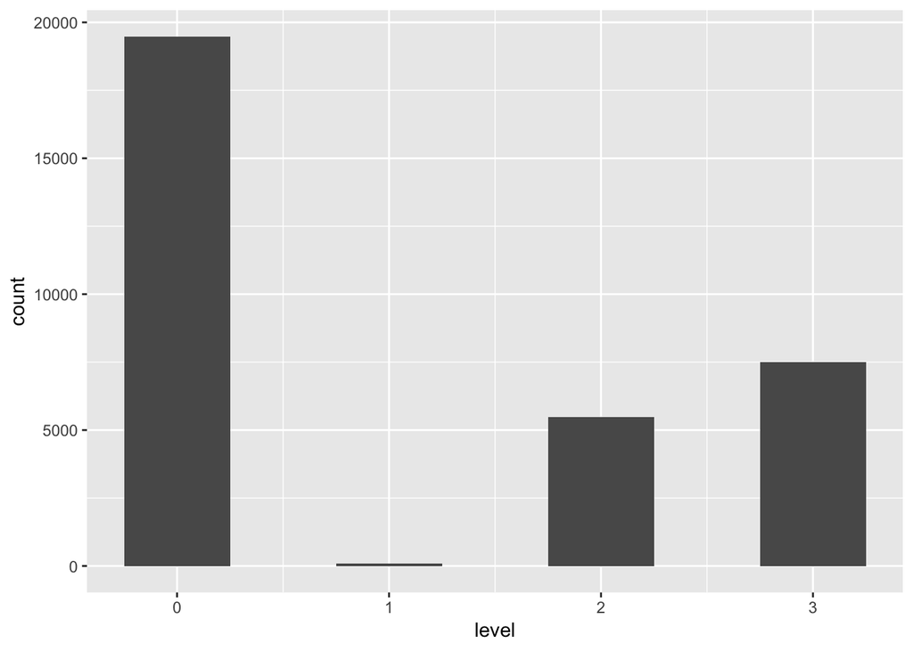

```r
(histogram <- ggplot(data.frame(y.pred), aes(x = y.pred)) +
        geom_histogram() + stat_bin(binwidth = 0.5)) + labs(x = 'level')
```

```r
cm$overall
```

```
##       Accuracy          Kappa  AccuracyLower  AccuracyUpper   AccuracyNull
##      0.5660441      0.4219826      0.5606392      0.5714372      0.2564662
## AccuracyPValue  McnemarPValue
##      0.0000000      0.0000000
```

- We can see that the overall accuracy is around 60%, which is acceptable. Now we take a look at the statistics by class:

```r
cm$byClass
```

```
##          Sensitivity Specificity Pos Pred Value Neg Pred Value Precision
## Class: 0 0.998531392   0.5355371      0.4187538      0.9990819 0.4187538
## Class: 1 0.004192119   0.9975212      0.3684211      0.7438615 0.3684211
## Class: 2 0.536674202   0.9510817      0.7803141      0.8637639 0.7803141
## Class: 3 0.738354807   0.9371375      0.7947726      0.9157054 0.7947726
##               Recall         F1 Prevalence Detection Rate
## Class: 0 0.998531392 0.59005605  0.2509983    0.250629723
## Class: 1 0.004192119 0.00828991  0.2564662    0.001075137
## Class: 2 0.536674202 0.63595773  0.2445782    0.131258831
## Class: 3 0.738354807 0.76552566  0.2479572    0.183080420
##          Detection Prevalence Balanced Accuracy
## Class: 0          0.598513240         0.7670342
## Class: 1          0.002918228         0.5008566
## Class: 2          0.168212816         0.7438779
## Class: 3          0.230355717         0.8377461
```

# Random Forest

## Train and Tuning

```r
library(randomForest)
tuning.mtry <- c(2, 3, 4)
tuning.nodesize <- c(10, 4, 2)
mis.error <- matrix(data = NA, nrow = 3, ncol = 3)
j = 1
for (nodesize in tuning.nodesize) {
  i = 1
  for (mtry in tuning.mtry) {
    rf.fit =randomForest(X.train,
                         as.factor(y.train),
                         ntree = 500,
                         mtry = mtry,
                         nodesize = nodesize
    )
    y.pred = predict(rf.fit, X.test)
    y.pred = as.numeric(y.pred) - 1
    mis.error[i, j] = 1 - (sum(as.factor(y.pred) == y.test) / length(y.test))
    i = i + 1
    print(paste0("node size: ", nodesize, ", mtry: ", mtry))
  }
  j = j + 1
}
```

```
## [1] "node size: 10, mtry: 2"
## [1] "node size: 10, mtry: 3"
## [1] "node size: 10, mtry: 4"
## [1] "node size: 4, mtry: 2"
## [1] "node size: 4, mtry: 3"
## [1] "node size: 4, mtry: 4"
## [1] "node size: 2, mtry: 2"
## [1] "node size: 2, mtry: 3"
## [1] "node size: 2, mtry: 4"
```

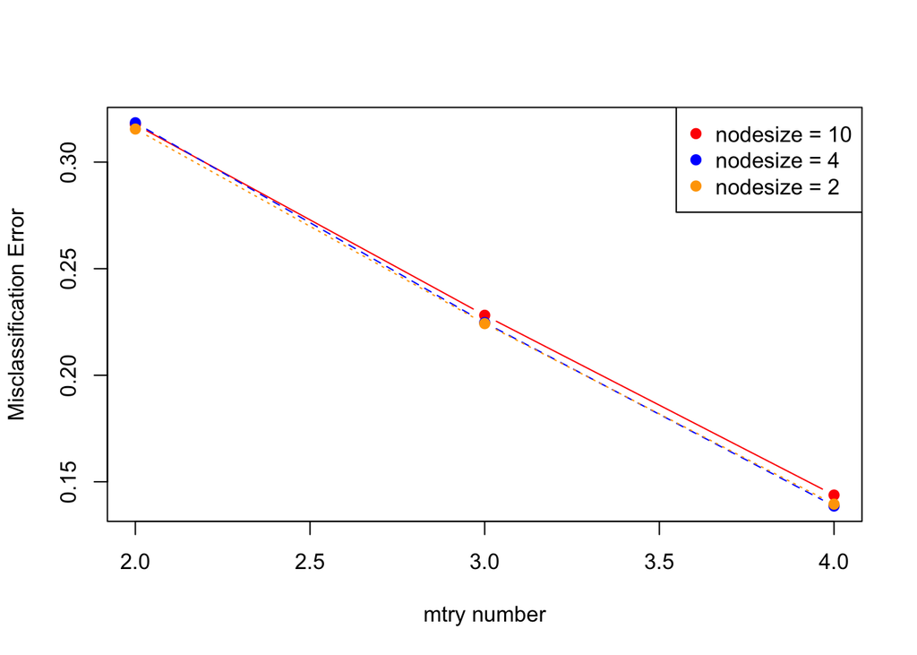

```r
matplot(tuning.mtry,
        mis.error,
        pch=19,
        col=c("red", "blue", "orange"),
        type="b",
        ylab="Misclassification Error",
        xlab="mtry number"
        )
legend("topright",
       legend=c("nodesize = 10", "nodesize = 4", "nodesize = 2"),
       pch=19,
       col=c("red", "blue", "orange"))
```

- For the parameter tuning, I selected several values of mtry around 3 which is the squareroot of the number of variables in the dataset (by convention). From the plot, we can see that with the nodesize = 4 and mtry number = 4, we get the lowest classification error on the test dataset.

## Best random forest model:

```r
model = randomForest(X.train, as.factor(y.train), ntree = 500, mtry = 4, nodesize=4)
```

## Predicting:

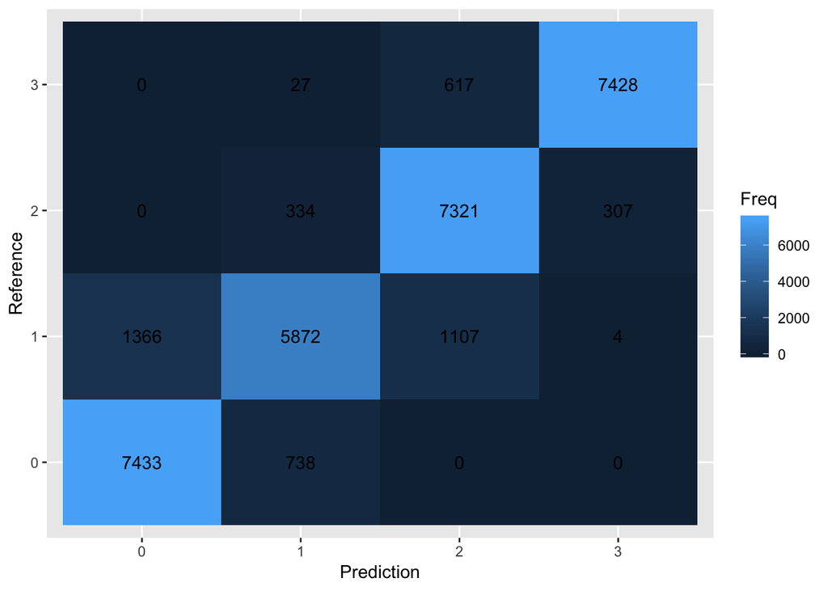

```r
y.pred <- predict(model, X.test)
y.pred <- as.numeric(y.pred)-1
cm <- confusionMatrix(as.factor(y.pred), as.factor(y.test))
ggplot(data = as.data.frame(cm$table), aes(x=Prediction, y=Reference, fill=Freq)) + geom_tile() + geom_text(aes(label = Freq))
```

## Histogram

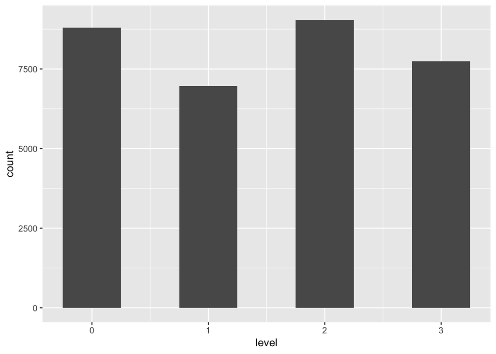

```r
(histogram <- ggplot(data.frame(y.pred), aes(x = y.pred)) +
        geom_histogram() + stat_bin(binwidth = 0.5)) + labs(x = 'level')
```